# Content

# 7. Feature Engineering

- Can be deleted unimportant features.

```python
data.drop(columns=['education', 'relationship', 'race', 'native.country'], inplace=True)
```

```python
data.head()
```

|  | age | workclass | fnlwgt | education.num | marital.status | occupation | sex | capital.gain | capital.loss | hours.per.week | income |
| --- | --- | --- | --- | --- | --- | --- | --- | --- | --- | --- | --- |
| 0 | 90 | Private | 77053 | 9 | Widowed | Prof-specialty | Female | 0 | 4356 | 40 | <=50K |
| 1 | 82 | Private | 132870 | 9 | Widowed | Exec-managerial | Female | 0 | 4356 | 18 | <=50K |
| 2 | 66 | Private | 186061 | 10 | Widowed | Prof-specialty | Female | 0 | 4356 | 40 | <=50K |
| 3 | 54 | Private | 140359 | 4 | Divorced | Machine-op-inspct | Female | 0 | 3900 | 40 | <=50K |
| 4 | 41 | Private | 264663 | 10 | Separated | Prof-specialty | Female | 0 | 3900 | 40 | <=50K |

- Split data on train - `70`% and testing - `30`%.

```python
X, y = data.drop(columns='income'), data['income'].map({'<=50K': 0, '>50K': 1})
X_train, X_test, y_train, y_test = train_test_split(X, y, test_size=0.3, random_state=42, shuffle=True, stratify=y)
```

- Standardization such features as `age`, `fnlwgt`, `capital.gain`, `capital.loss`, and `hours.per.week`.

```python
numeric_col = ['age', 'fnlwgt', 'capital.gain', 'capital.loss', 'hours.per.week']
```

```python
scaler = StandardScaler()
X_train_scaled = scaler.fit_transform(X_train[numeric_col])
X_test_scaled = scaler.transform(X_test[numeric_col])
```

- One-hot encoding such features as `workclass`, `marital.status`, and `occupation`.

```python
nominal_col = ['workclass', 'marital.status', 'occupation']
```

```python
one_hot_encoder = OneHotEncoder(sparse=False, handle_unknown='ignore')
X_train_encoded = one_hot_encoder.fit_transform(X_train[nominal_col])
X_test_encoded = one_hot_encoder.transform(X_test[nominal_col])
```

- Ordinal encoding feature `education.num`.

```python
ordinal_col = ['education.num']
```

```python
ordinal_encoder = OrdinalEncoder()
X_train_encoded = np.concatenate([X_train_encoded, ordinal_encoder.fit_transform(X_train[ordinal_col])], axis=1)
X_test_encoded = np.concatenate([X_test_encoded, ordinal_encoder.transform(X_test[ordinal_col])], axis=1)
```

- Binary encoding feature `sex`.

```python
binary_col = ['sex']
```

```python
binary_encoder = OrdinalEncoder()
X_train_encoded = np.concatenate([X_train_encoded, binary_encoder.fit_transform(X_train[binary_col])], axis=1)
X_test_encoded = np.concatenate([X_test_encoded, binary_encoder.transform(X_test[binary_col])], axis=1)
```

- Processed X_train and X_test.

```python
X_train_processed = np.concatenate([X_train_scaled, X_train_encoded], axis=1)
X_test_processed = np.concatenate([X_test_scaled, X_test_encoded], axis=1)
```

# 8. Data Modeling

## 8.1. SGD Lasso

```python
clf = SGDClassifier(loss='hinge', penalty='l1', alpha=0.0001, learning_rate='optimal')
clf.fit(X_train_processed, y_train)
y_pred_sgd_lasso = clf.predict(X_test_processed)
```

```python
accuracy_sgd_lasso = accuracy_score(y_test, y_pred_sgd_lasso)
print(f"Accuracy: {accuracy_sgd_lasso}")
```

```
Accuracy: 0.8373284163081336
```

```python
estimator_sgd_lasso = Pipeline(steps=[
    ('features_processing', FeatureUnion(transformer_list=[
        ('numerical_features_processing', Pipeline(steps=[('selecting', FunctionTransformer(lambda data: data[numeric_col])),
                                                          ('scaler', StandardScaler())])),
        ('nominal_features_processing', Pipeline(steps=[('selecting', FunctionTransformer(lambda data: data[nominal_col])),
                                                        ('one_hot_encoder', OneHotEncoder(handle_unknown='ignore'))])),
        ('ordinal_features_processing', Pipeline(steps=[('selecting', FunctionTransformer(lambda data: data[ordinal_col])),
                                                        ('ordinal_encoder', OrdinalEncoder())])),
        ('binary_features_processing', Pipeline(steps=[('selecting', FunctionTransformer(lambda data: data[binary_col])),
                                                       ('binary_encoding', OrdinalEncoder())]))])),
    ('model', SGDClassifier(loss='hinge', penalty='l1', alpha=0.0001, learning_rate='optimal'))])
```

```python
cv_sgd_lasso = cross_val_score(estimator_sgd_lasso, X, y, scoring='accuracy', cv=3).mean()
print(f"CV accuracy: {cv_sgd_lasso}")
```

```
CV accuracy: 0.816270912775504
```

### Classification report

```python
print(classification_report(y_test, y_pred_sgd_lasso))
```

```
              precision    recall  f1-score   support

           0       0.91      0.87      0.89      7410
           1       0.64      0.73      0.68      2352

    accuracy                           0.84      9762
   macro avg       0.78      0.80      0.79      9762
weighted avg       0.85      0.84      0.84      9762
```

## 8.2. Ridge

```python
clf = RidgeClassifier(alpha=1)
clf.fit(X_train_processed, y_train)
y_pred_ridge = clf.predict(X_test_processed)
```

```python
accuracy_ridge = accuracy_score(y_test, y_pred_ridge)
print(f"Accuracy: {accuracy_ridge}")
```

```
Accuracy: 0.8355869698832207
```

```python
estimator_ridge = Pipeline(steps=[
    ('features_processing', FeatureUnion(transformer_list=[
        ('numerical_features_processing', Pipeline(steps=[('selecting', FunctionTransformer(lambda data: data[numeric_col])),
                                                          ('scaler', StandardScaler())])),
        ('nominal_features_processing', Pipeline(steps=[('selecting', FunctionTransformer(lambda data: data[nominal_col])),
                                                        ('one_hot_encoder', OneHotEncoder(handle_unknown='ignore'))])),
        ('ordinal_features_processing', Pipeline(steps=[('selecting', FunctionTransformer(lambda data: data[ordinal_col])),
                                                        ('ordinal_encoder', OrdinalEncoder())])),
        ('binary_features_processing', Pipeline(steps=[('selecting', FunctionTransformer(lambda data: data[binary_col])),
                                                       ('binary_encoding', OrdinalEncoder())]))])),
    ('model', RidgeClassifier(alpha=1))])
```

```python
cv_ridge = cross_val_score(estimator_ridge, X, y, scoring='accuracy', cv=3).mean()
print(f"CV accuracy: {cv_ridge}")
```

```
CV accuracy: 0.8235238347128458
```

### Classification report

```python
print(classification_report(y_test, y_pred_ridge))
```

```
              precision    recall  f1-score   support

           0       0.86      0.94      0.90      7410
           1       0.73      0.51      0.60      2352

    accuracy                           0.84      9762
   macro avg       0.79      0.72      0.75      9762
weighted avg       0.83      0.84      0.82      9762
```

## 8.3. SGD Ridge

```python
clf = SGDClassifier(loss='hinge', penalty='l2', alpha=0.0001, learning_rate='optimal')
clf.fit(X_train_processed, y_train)
y_pred_sgd_ridge = clf.predict(X_test_processed)
```

```python
accuracy_sgd_ridge = accuracy_score(y_test, y_pred_sgd_ridge)
print(f"Accuracy: {accuracy_sgd_ridge}")
```

```
Accuracy: 0.8455234583077238
```

```python
estimator_sgd_ridge = Pipeline(steps=[
    ('features_processing', FeatureUnion(transformer_list=[
        ('numerical_features_processing', Pipeline(steps=[('selecting', FunctionTransformer(lambda data: data[numeric_col])),
                                                          ('scaler', StandardScaler())])),
        ('nominal_features_processing', Pipeline(steps=[('selecting', FunctionTransformer(lambda data: data[nominal_col])),
                                                        ('one_hot_encoder', OneHotEncoder(handle_unknown='ignore'))])),
        ('ordinal_features_processing', Pipeline(steps=[('selecting', FunctionTransformer(lambda data: data[ordinal_col])),
                                                        ('ordinal_encoder', OrdinalEncoder())])),
        ('binary_features_processing', Pipeline(steps=[('selecting', FunctionTransformer(lambda data: data[binary_col])),
                                                       ('binary_encoding', OrdinalEncoder())]))])),
    ('model', SGDClassifier(loss='hinge', penalty='l2', alpha=0.0001, learning_rate='optimal'))])
```

```python
cv_sgd_ridge = cross_val_score(estimator_sgd_ridge, X, y, scoring='accuracy', cv=3).mean()
print(f"CV accuracy: {cv_sgd_ridge}")
```

```
CV accuracy: 0.8056065892641016
```

### Classification report

```python
print(classification_report(y_test, y_pred_sgd_ridge))
```

```
              precision    recall  f1-score   support

           0       0.86      0.95      0.90      7410
           1       0.76      0.53      0.62      2352

    accuracy                           0.85      9762
   macro avg       0.81      0.74      0.76      9762
weighted avg       0.84      0.85      0.84      9762
```

## 8.4. Logistic Regression

```python
clf = LogisticRegression(penalty='l2', C=0.5, max_iter=600)
clf.fit(X_train_processed, y_train)
y_pred_log_regr = clf.predict(X_test_processed)
```

```python
accuracy_log_regr = accuracy_score(y_test, y_pred_log_regr)
print(f"Accuracy: {accuracy_log_regr}")
```

```
Accuracy: 0.8492112272075394
```

```python
estimator_log_regr = Pipeline(steps=[
    ('features_processing', FeatureUnion(transformer_list=[
        ('numerical_features_processing', Pipeline(steps=[('selecting', FunctionTransformer(lambda data: data[numeric_col])),
                                                          ('scaler', StandardScaler())])),
        ('nominal_features_processing', Pipeline(steps=[('selecting', FunctionTransformer(lambda data: data[nominal_col])),
                                                        ('one_hot_encoder', OneHotEncoder(handle_unknown='ignore'))])),
        ('ordinal_features_processing', Pipeline(steps=[('selecting', FunctionTransformer(lambda data: data[ordinal_col])),
                                                        ('ordinal_encoder', OrdinalEncoder())])),
        ('binary_features_processing', Pipeline(steps=[('selecting', FunctionTransformer(lambda data: data[binary_col])),
                                                       ('binary_encoding', OrdinalEncoder())]))])),
    ('model', LogisticRegression(penalty='l2', C=0.5, max_iter=600))])
```

```python
cv_log_regr = cross_val_score(estimator_log_regr, X, y, scoring='accuracy', cv=3).mean()
print(f"CV accuracy: {cv_log_regr}")
```

```
CV accuracy: 0.8234316829992387
```

### Classification report

```python
print(classification_report(y_test, y_pred_log_regr))
```

```
              precision    recall  f1-score   support

           0       0.88      0.93      0.90      7410
           1       0.73      0.59      0.65      2352

    accuracy                           0.85      9762
   macro avg       0.80      0.76      0.78      9762
weighted avg       0.84      0.85      0.84      9762
```

## 8.5. SVM Linear

```python
clf = LinearSVC(penalty='l2', loss='squared_hinge', C=1, max_iter=9000)
clf.fit(X_train_processed, y_train)
y_pred_svm_linear = clf.predict(X_test_processed)
```

```python
accuracy_svm_linear = accuracy_score(y_test, y_pred_svm_linear)
print(f"Accuracy: {accuracy_svm_linear}")
```

```
Accuracy: 0.8480844089325957
```

```python
estimator_svm_linear = Pipeline(steps=[
    ('features_processing', FeatureUnion(transformer_list=[
        ('numerical_features_processing', Pipeline(steps=[('selecting', FunctionTransformer(lambda data: data[numeric_col])),
                                                          ('scaler', StandardScaler())])),
        ('nominal_features_processing', Pipeline(steps=[('selecting', FunctionTransformer(lambda data: data[nominal_col])),
                                                        ('one_hot_encoder', OneHotEncoder(handle_unknown='ignore'))])),
        ('ordinal_features_processing', Pipeline(steps=[('selecting', FunctionTransformer(lambda data: data[ordinal_col])),
                                                        ('ordinal_encoder', OrdinalEncoder())])),
        ('binary_features_processing', Pipeline(steps=[('selecting', FunctionTransformer(lambda data: data[binary_col])),
                                                       ('binary_encoding', OrdinalEncoder())]))])),
    ('model', LinearSVC(penalty='l2', loss='squared_hinge', C=1, max_iter=9000))])
```

```python
cv_svm_linear = cross_val_score(estimator_svm_linear, X, y, scoring='accuracy', cv=3).mean()
print(f"CV accuracy: {cv_svm_linear}")
```

```
CV accuracy: 0.8221715413302192
```

### Classification report

```python
print(classification_report(y_test, y_pred_svm_linear))
```

```
              precision    recall  f1-score   support

           0       0.87      0.93      0.90      7410
           1       0.73      0.58      0.65      2352

    accuracy                           0.85      9762
   macro avg       0.80      0.76      0.78      9762
weighted avg       0.84      0.85      0.84      9762
```

## 8.6. SVM Polynomial

```python
clf = SVC(C=1, kernel='poly', degree=3)
clf.fit(X_train_processed, y_train)
y_pred_svm_poly = clf.predict(X_test_processed)
```

```python
accuracy_svm_poly = accuracy_score(y_test, y_pred_svm_poly)
print(f"Accuracy: {accuracy_svm_poly}")
```

```
Accuracy: 0.848699037082565
```

```python
estimator_svm_poly = Pipeline(steps=[
    ('features_processing', FeatureUnion(transformer_list=[
        ('numerical_features_processing', Pipeline(steps=[('selecting', FunctionTransformer(lambda data: data[numeric_col])),
                                                          ('scaler', StandardScaler())])),
        ('nominal_features_processing', Pipeline(steps=[('selecting', FunctionTransformer(lambda data: data[nominal_col])),
                                                        ('one_hot_encoder', OneHotEncoder(handle_unknown='ignore'))])),
        ('ordinal_features_processing', Pipeline(steps=[('selecting', FunctionTransformer(lambda data: data[ordinal_col])),
                                                        ('ordinal_encoder', OrdinalEncoder())])),
        ('binary_features_processing', Pipeline(steps=[('selecting', FunctionTransformer(lambda data: data[binary_col])),
                                                       ('binary_encoding', OrdinalEncoder())]))])),
    ('model', SVC(C=1, kernel='poly', degree=3))])
```

```python
cv_svm_poly = cross_val_score(estimator_svm_poly, X, y, scoring='accuracy', cv=3).mean()
print(f"CV accuracy: {cv_svm_poly}")
```

```
CV accuracy: 0.8231242593509348
```

### Classification report

```python
print(classification_report(y_test, y_pred_svm_poly))
```

```
              precision    recall  f1-score   support

           0       0.86      0.95      0.91      7410
           1       0.77      0.53      0.63      2352

    accuracy                           0.85      9762
   macro avg       0.82      0.74      0.77      9762
weighted avg       0.84      0.85      0.84      9762
```

## 8.7. K-Nearest Neighbors

```python
clf = KNeighborsClassifier(n_neighbors=15, weights='uniform', p=2, metric='minkowski')
clf.fit(X_train_processed, y_train)
y_pred_knn = clf.predict(X_test_processed)
```

```python
accuracy_knn = accuracy_score(y_test, y_pred_knn)
print(f"Accuracy: {accuracy_knn}")
```

```
Accuracy: 0.8454210202827289
```

```python
estimator_knn = Pipeline(steps=[
    ('features_processing', FeatureUnion(transformer_list=[
        ('numerical_features_processing', Pipeline(steps=[('selecting', FunctionTransformer(lambda data: data[numeric_col])),
                                                          ('scaler', StandardScaler())])),
        ('nominal_features_processing', Pipeline(steps=[('selecting', FunctionTransformer(lambda data: data[nominal_col])),
                                                        ('one_hot_encoder', OneHotEncoder(handle_unknown='ignore'))])),
        ('ordinal_features_processing', Pipeline(steps=[('selecting', FunctionTransformer(lambda data: data[ordinal_col])),
                                                        ('ordinal_encoder', OrdinalEncoder())])),
        ('binary_features_processing', Pipeline(steps=[('selecting', FunctionTransformer(lambda data: data[binary_col])),
                                                       ('binary_encoding', OrdinalEncoder())]))])),
    ('model', KNeighborsClassifier(n_neighbors=15, weights='uniform', p=2, metric='minkowski'))])
```

```python
cv_knn = cross_val_score(estimator_knn, X, y, scoring='accuracy', cv=3).mean()
print(f"CV accuracy: {cv_knn}")
```

```
CV accuracy: 0.8272428526382217
```

### Classification report

```python
print(classification_report(y_test, y_pred_knn))
```

```
              precision    recall  f1-score   support

           0       0.88      0.92      0.90      7410
           1       0.71      0.61      0.66      2352

    accuracy                           0.85      9762
   macro avg       0.79      0.77      0.78      9762
weighted avg       0.84      0.85      0.84      9762
```

## 8.8. Decision Tree

```python
clf = DecisionTreeClassifier(criterion='gini', max_depth=10, min_samples_split=5, min_samples_leaf=1, max_features=None)
clf.fit(X_train_processed, y_train)
y_pred_tree = clf.predict(X_test_processed)
```

```python
accuracy_tree = accuracy_score(y_test, y_pred_tree)
print(f"Accuracy: {accuracy_tree}")
```

```
Accuracy: 0.8511575496824422
```

```python
estimator_tree = Pipeline(steps=[
    ('features_processing', FeatureUnion(transformer_list=[
        ('numerical_features_processing', Pipeline(steps=[('selecting', FunctionTransformer(lambda data: data[numeric_col])),
                                                          ('scaler', StandardScaler())])),
        ('nominal_features_processing', Pipeline(steps=[('selecting', FunctionTransformer(lambda data: data[nominal_col])),
                                                        ('one_hot_encoder', OneHotEncoder(handle_unknown='ignore'))])),
        ('ordinal_features_processing', Pipeline(steps=[('selecting', FunctionTransformer(lambda data: data[ordinal_col])),
                                                        ('ordinal_encoder', OrdinalEncoder())])),
        ('binary_features_processing', Pipeline(steps=[('selecting', FunctionTransformer(lambda data: data[binary_col])),
                                                       ('binary_encoding', OrdinalEncoder())]))])),
    ('model', DecisionTreeClassifier(criterion='gini', max_depth=10, min_samples_split=5, min_samples_leaf=1,
                                     max_features=None))])
```

```python
cv_tree = cross_val_score(estimator_tree, X, y, scoring='accuracy', cv=3).mean()
print(f"CV accuracy: {cv_tree}")
```

```
CV accuracy: 0.8210651879997828
```

### Classification report

```python
print(classification_report(y_test, y_pred_tree))
```

```
              precision    recall  f1-score   support

           0       0.88      0.92      0.90      7410
           1       0.72      0.62      0.67      2352

    accuracy                           0.85      9762
   macro avg       0.80      0.77      0.79      9762
weighted avg       0.85      0.85      0.85      9762
```

## 8.9. Random Forest

```python
clf = RandomForestClassifier(n_estimators=100, criterion='gini', min_samples_split=5, min_samples_leaf=1, max_features='sqrt',
                             bootstrap=True, n_jobs=-1)
clf.fit(X_train_processed, y_train)
y_pred_forest = clf.predict(X_test_processed)
```

```python
accuracy_forest = accuracy_score(y_test, y_pred_forest)
print(f"Accuracy: {accuracy_forest}")
```

```
Accuracy: 0.8582257734070887
```

```python
estimator_forest = Pipeline(steps=[
    ('features_processing', FeatureUnion(transformer_list=[
        ('numerical_features_processing', Pipeline(steps=[('selecting', FunctionTransformer(lambda data: data[numeric_col])),
                                                          ('scaler', StandardScaler())])),
        ('nominal_features_processing', Pipeline(steps=[('selecting', FunctionTransformer(lambda data: data[nominal_col])),
                                                        ('one_hot_encoder', OneHotEncoder(handle_unknown='ignore'))])),
        ('ordinal_features_processing', Pipeline(steps=[('selecting', FunctionTransformer(lambda data: data[ordinal_col])),
                                                        ('ordinal_encoder', OrdinalEncoder())])),
        ('binary_features_processing', Pipeline(steps=[('selecting', FunctionTransformer(lambda data: data[binary_col])),
                                                       ('binary_encoding', OrdinalEncoder())]))
    ])),
    ('model', RandomForestClassifier(n_estimators=100, criterion='gini', min_samples_split=5, min_samples_leaf=1,
                                     max_features='sqrt', bootstrap=True, n_jobs=-1))])
```

```python
cv_forest = cross_val_score(estimator_forest, X, y, scoring='accuracy', cv=3).mean()
print(f"CV accuracy: {cv_forest}")
```

```
CV accuracy: 0.8272428583059575
```

### Classification report

```python
print(classification_report(y_test, y_pred_forest))
```

```
              precision    recall  f1-score   support

           0       0.89      0.93      0.91      7410
           1       0.75      0.62      0.68      2352

    accuracy                           0.86      9762
   macro avg       0.82      0.78      0.79      9762
weighted avg       0.85      0.86      0.85      9762
```

## 8.10. XGBoost

```python
clf = XGBClassifier(max_depth=3, learning_rate=0.1, n_estimators=100)
clf.fit(X_train_processed, y_train)
y_pred_xgb = clf.predict(X_test_processed)
```

```python
accuracy_xgb = accuracy_score(y_test, y_pred_xgb)
print(f"Accuracy: {accuracy_xgb}")
```

```
Accuracy: 0.8628354845318582
```

```python
estimator_xgb = Pipeline(steps=[
    ('features_processing', FeatureUnion(transformer_list=[
        ('numerical_features_processing', Pipeline(steps=[('selecting', FunctionTransformer(lambda data: data[numeric_col])),
                                                          ('scaler', StandardScaler())])),
        ('nominal_features_processing', Pipeline(steps=[('selecting', FunctionTransformer(lambda data: data[nominal_col])),
                                                        ('one_hot_encoder', OneHotEncoder(handle_unknown='ignore'))])),
        ('ordinal_features_processing', Pipeline(steps=[('selecting', FunctionTransformer(lambda data: data[ordinal_col])),
                                                        ('ordinal_encoder', OrdinalEncoder())])),
        ('binary_features_processing', Pipeline(steps=[('selecting', FunctionTransformer(lambda data: data[binary_col])),
                                                       ('binary_encoding', OrdinalEncoder())]))])),
    ('model', XGBClassifier(max_depth=3, learning_rate=0.1, n_estimators=100))])
```

```python
cv_xgb = cross_val_score(estimator_xgb, X, y, scoring='accuracy', cv=3).mean()
print(f"CV accuracy: {cv_xgb}")
```

```
CV accuracy: 0.828933056419106
```

### Classification report

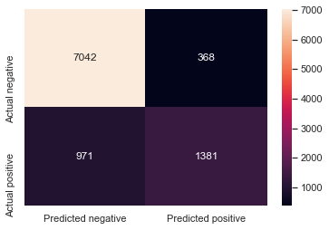

```python
sns.heatmap(confusion_matrix(y_test, y_pred_xgb, labels=[0, 1]), fmt='.0f', annot=True,
            xticklabels=['Predicted negative', 'Predicted positive'], yticklabels=['Actual negative', 'Actual positive']);
```

```python
print(classification_report(y_test, y_pred_xgb))
```

```
              precision    recall  f1-score   support

           0       0.88      0.95      0.91      7410
           1       0.79      0.59      0.67      2352

    accuracy                           0.86      9762
   macro avg       0.83      0.77      0.79      9762
weighted avg       0.86      0.86      0.86      9762
```

- As the threshold increases, we make less FP and more FN errors.

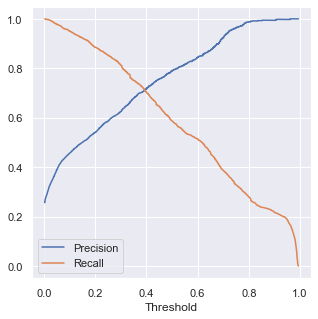

```python
precision, recall, thresholds = precision_recall_curve(y_test, clf.predict_proba(X_test_processed)[:, 1])

plt.figure(figsize=(5, 5))
plt.plot(thresholds, precision[:-1], label='Precision')
plt.plot(thresholds, recall[:-1], label='Recall')

plt.xlabel('Threshold')
plt.legend();
```

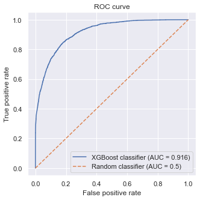

```python
fpr, tpr, thresholds = roc_curve(y_test, clf.predict_proba(X_test_processed)[:, 1])
auc_xgb = roc_auc_score(y_test, clf.predict_proba(X_test_processed)[:, 1])

plt.figure(figsize=(5, 5))
plt.plot(fpr, tpr, label=f"XGBoost classifier (AUC = {auc_xgb:.3f})")
plt.plot([0, 1], [0, 1], '--', label="Random classifier (AUC = 0.5)")

plt.title("ROC curve")
plt.xlabel("False positive rate")
plt.ylabel("True positive rate")
plt.legend();
```

```python
idx = np.argmin(euclidean_distances(list(zip(fpr, tpr)), [[0, 1]]))
best_threshold = thresholds[idx]
print(f"Best threshold: {best_threshold}")
```

```
Best threshold: 0.27362802624702454
```